# Part II - Effect of Loan Characteristics on the Loans

## by Oyedele Samuel

## Investigation Overview

## Dataset Overview

> The dataset contains 113,937 loans with 81 variables including loan original amount, current loan status, term, prosper score, borrower rate (or interest rate),borrower income, and many others. A subset dataset of 77,543 loans with 20 variables was used for better exploration after data warangling.

## Distribution of Loan Original Amount

> The loan original amount distribution is trimodal, with one peak at 5000, second peak at 10000, and third peak at 15000. There's a low decrease in frequency of loan amount after 25000.

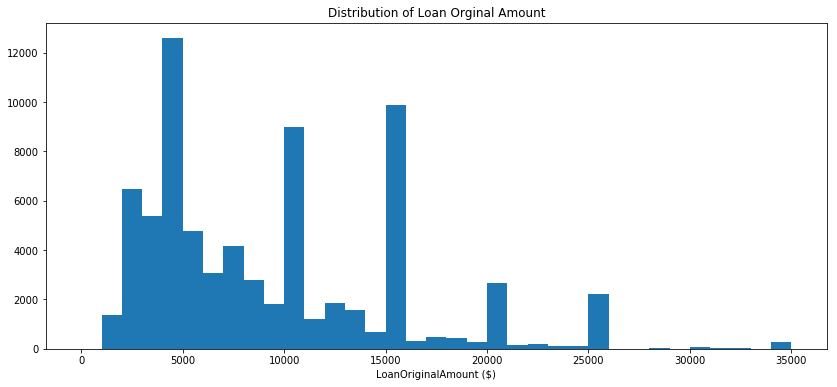

## Distribution of Income Range

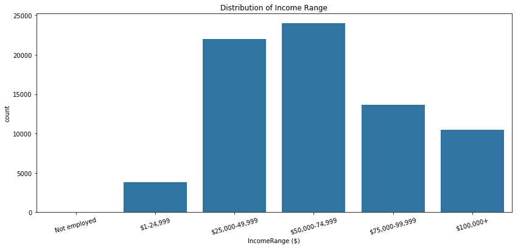

## Distribution of Debt To Income Ratio

> From the distribution above, loan lenders tend to give more loans to borrowers with low debt income ratio (< 0.36). There's large spikes in frequency from range (0 - 0.36).

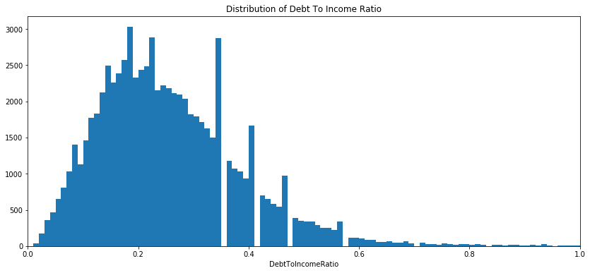

## Distribution of Monthly Loan Payment

> This distribution is unimodal. Monthly loan payment is slightly skewed right where more loans in the range of 0 - 500 monthly payment.

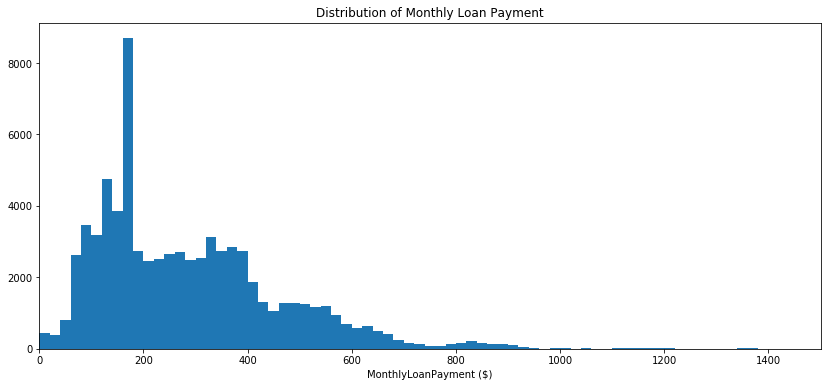

## Distribution of Is Borrower Home Owner

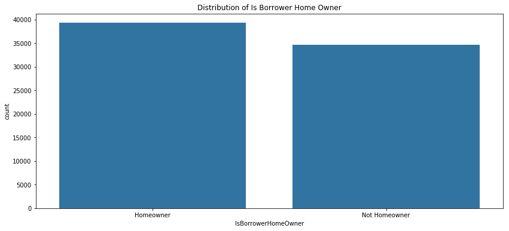

## Loan Original Amount vs. Income Range

> From the plot below, the higher the income range, the higher the loan amounts given.

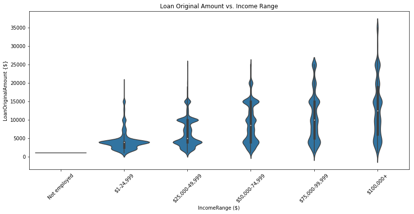

## Loan Original Amount vs. Monthly Loan Payment

> There is a strong relationship between loan original amount and monthly loan payment. The higher the loan amount, the higher the monthly loan payment.

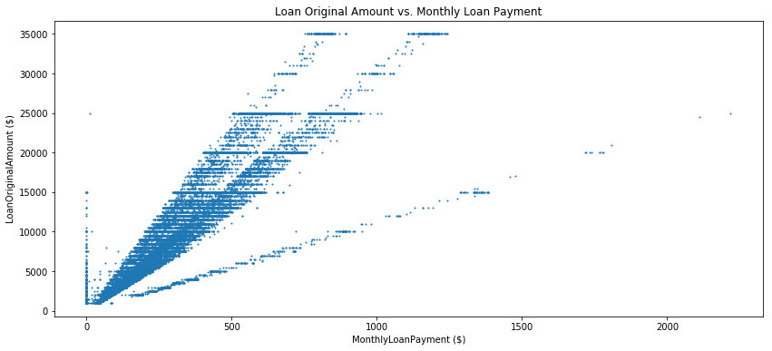

## Loan Original Amount vs. Loan Status

> From the plot below, an average loan amounts of 5,000 are completed while average loan amounts of 10,000 are current.

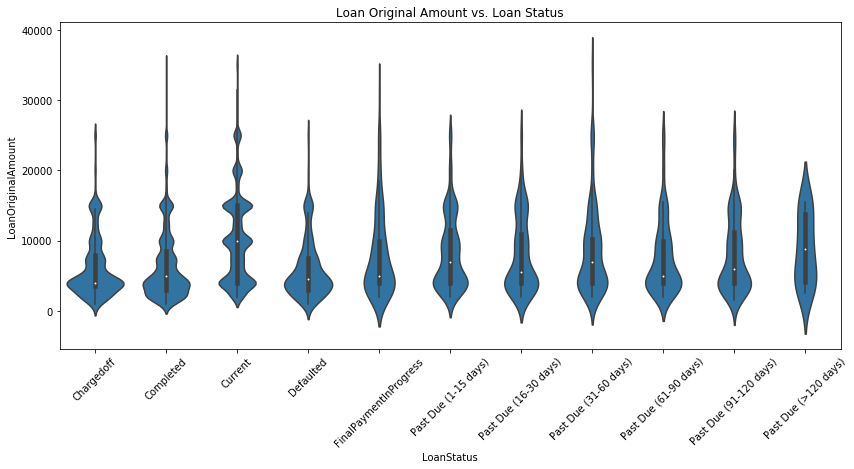

## Monthly Loan Payment vs. Stated Monthly Income

> There's a weak postive relationship between them.

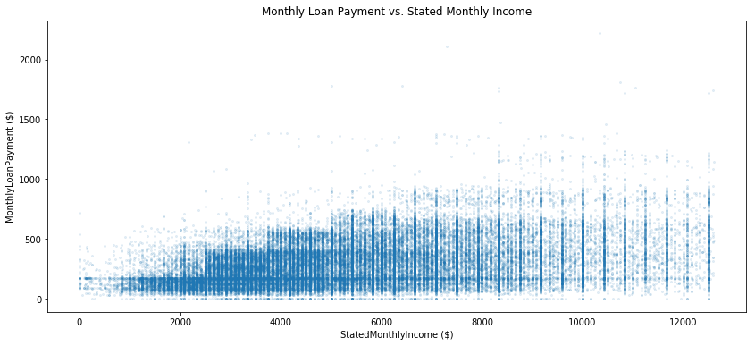

## Loan Original Amount and Monthly Loan Payment by Loan Origination Year

> There is a increase in loan original amount and monthly loan payment across the year. This show a postive interaction between the numeric variables and categorical variables.

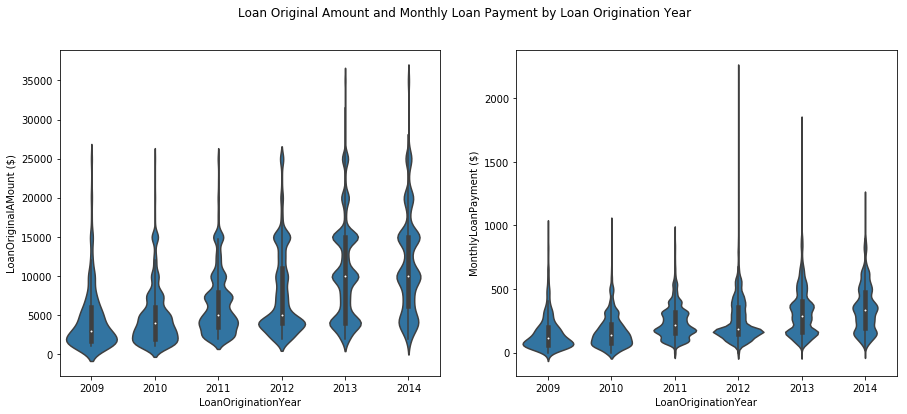